# Kategorická data a procenta

## Titulek v Hospodářských novinách

> “Na koronavirus letos [2021] zemřelo 24 tisíc Čechů, 80 procent z nich nebylo očkovaných.”

Co na základě tohoto výroku můžeme říct o účinnosti vakcín?

[Celý článek HN](https://domaci.hn.cz/c1-67017640-na-koronavirus-letos-zemrelo-24-tisic-cechu-80-procent-z-nich-nebylo-ockovanych)

## Přehlížení výchozí pravděpodobnosti

Base rate fallacy

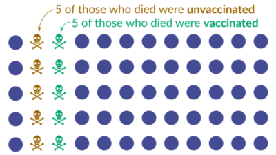

## Přehlížení výchozí pravděpodobnosti

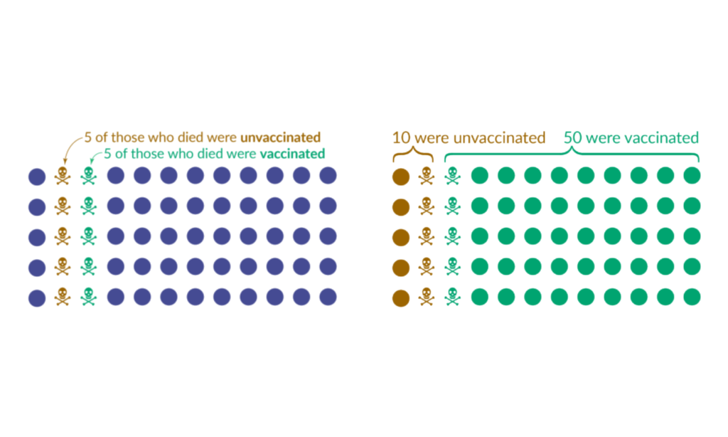

[Zdroj obrázků Our World in Data](https://ourworldindata.org/covid-deaths-by-vaccination)

## Není většina jako většina

> Titulek na Britských listech: “Proč většina lidí, kteří už byli očkováni, nyní v Anglii umírá na covid?”

To naštěstí není pravda. Ale většina umírajících jsou očkovaní. Pokud neznáme výchozí podíl očkovaných a neočkovaných, nic moc nám to neříká.

[Celý článek BL](https://blisty.cz/art/104272-proc-vetsina-lidi-kteri-uz-byli-ockovani-nyni-v-anglii-umira-na-covid.html)

## Binární proměnné

0 vs. 1

## Relativní vs. absolutní riziko

- Studie 1,3 miliónu pacientů, 3000 chirurgů za období 2007 až 2019

> Women 32% more likely to die after operation by male surgeon, study reveals

> —[The Guardian](https://www.theguardian.com/society/2022/jan/04/women-more-likely-die-operation-male-surgeon-study)

Jde o relativní, nebo absolutní risk?

## Je 32 % malé nebo velké číslo?

- Zvýšení ze 3 z 10 na 4 z 10
- Zvýšení z 3 z miliónu na 4 z miliónu

Obojí představuje zvýšení relativního rizika třetinu (32 %).

## Jaké bylo absolutní riziko úmrtí v této studii pro ženy?

- 5 z 1000, když operovala žena
- 6,6 z tisíce, když operoval muž

Nárůst absolutního rizika pro ženy tak odpovídal jednomu úmrtí navíc pro každých cca 625 operací žen prováděných mužskými chirurgy.

## Závěr?

Relativní riziko samo o sobě může být zavádějící. V tomto případě jde o potenciálně závažné zjištění, i když rozdíl v absolutním riziku možná neodpovídá představám, které budil novinový titulek. Dobrým dalším krokem pro postavení věci do perspektivy by mohlo být porovnání s jinými faktory (například jak se od sebe liší různé nemocnice?) a přemýšlení o kauzálním mechanismu.

- Jaký kauzální mechanismus by podle vás mohl působit?

## Absolutní vs. Relativní riziko - definice

### Absolutní riziko

Podíl lidí ve vymezené skupině, kteří v určeném časovém období prožijí sledovanou událost.

### Relativní riziko

Když absolutní riziko u lidí, kteří jsou vystaveni působení zkoumaného jevu, označíme jako \(p\) a absolutní riziko u lidí, kteří jevu vystaveni nejsou, označíme jako \(q\), pak relativní riziko můžeme definovat jako \(p/q\).

## Jak komunikovat binární proměnné

## Různé způsoby komunikace binárních proměnných

Tabulka shrnuje možné způsoby komunikace příkladu výše: úmrtí operovaných žen, když operuje žena, resp. když operuje muž.

| Ukazatel | Operuje žena | Operuje muž |
| --- | --- | --- |
| pravděpodobnost (absolutní riziko) | 0.5 % | 0.66 % |
| očekávaná četnost | 5 ze 1000 | 6.6 ze 1000 |
| také očekávaná četnost | 1 z 200 | 1 z 152 |
| šance | 5 / 995 | 6.6 / 993.4 |

- Zkuste na základě tabulky definovat, co je to šance.

## Různé způsoby srovnání mezi dvěma skupinami

Tabulka shrnuje různé způsoby, jak ze dvou různých čísel pro dvě různé skupiny udělat jedno číslo, které v sobě obsahuje srovnání.

| Komparativní ukazatel | Hodnota |
| --- | --- |
| Rozdíl v absolutním riziku | 0.16 % |
| Relativní riziko | 6.6 / 5 = 1.32, tedy 32% nárůst |
| Number Needed to Treat (NNT) | 100 / 0.16 = 625 |
| Poměr šancí | (6.6 / 993.4) / (5 / 995) = 1.32 |

## Obě tabulky pro srovnání

| Ukazatel | Operuje žena | Operuje muž |
| --- | --- | --- |
| pravděpodobnost (absolutní riziko) | 0.5 % | 0.66 % |
| očekávaná četnost | 5 ze 1000 | 6.6 ze 1000 |
| také očekávaná četnost | 1 z 200 | 1 z 152 |
| šance | 5 / 995 | 6.6 / 993.4 |

| Komparativní ukazatel | Hodnota |
| --- | --- |
| Rozdíl v absolutním riziku | 0.16 % |
| Relativní riziko | 6.6 / 5 = 1.32, tedy 32% nárůst |
| Number Needed to Treat (NNT) | 100 / 0.16 = 625 |
| Poměr šancí | (6.6 / 993.4) / (5 / 995) = 1.32 |

## Pravděpodobnost

\[\frac{\textrm{úspěchy}}{\textrm{pokusy}}\] Pohybuje se od 0 do 1, případně od 0 % do 100 %.

## Očekávané četnosti

Co to znamená pro 100 lidí? Tisíc lidí? V mnoha situacích asi srozumitelněší forma než pravděpodobnost.

Viz např. [tuto studii v Cochrane Database](https://pubmed.ncbi.nlm.nih.gov/21412897/).

## Očekávané četnosti lze komunikovat také graficky

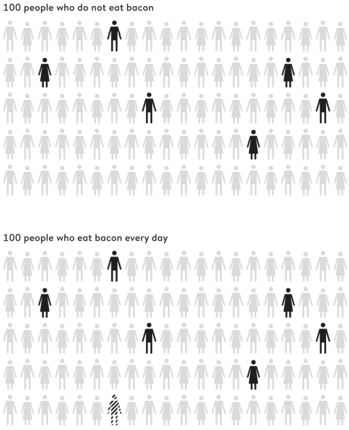

Zdroj obrázku Spiegelhalter (2019)

## Šance

Angličtina zná termíny “chance” a “odds.” Čeština oba překládá jako šance. To může být matoucí. Šance (chance) je neformální pojem, ale šance (odds) je ve statistice pojem jasně definovaný: poměr pozorování, kdy určitý jev nastane, a pozorování, kdy nenastane.

Tedy:

\[\frac{\textrm{úspěchy}}{\textrm{neúspěchy}}\]

Případně za využití pravděpodobnosti:

\[\frac{p}{1-p}\]

## Number Needed to Treat (NNT)

Medicínský ukazatel. Může být užitečný i pro komunikaci ve společenských vědách: Například kolik dětí by muselo projít intervencí, aby o jedno dítě méne skončilo ve výchovném ústavu?

\[\frac{100}{\textrm{rozdíl v absolutním riziku v procentech}}\]

## Poměr šancí

Zrádný ukazatel, v tuhle chvíli nadstavba.

\[ \frac{\frac{\textrm{úspěchy}_{\:skupina1}}{\textrm{neúspěchy}_{\:skupina1}}}{\frac{\textrm{úspěchy}_{\:skupina2}}{\textrm{neúspěchy}_{\:skupina2}}} \]

## Proč je poměr šancí zrádný?

- V příkladu výše vycházel stejně jako relativní riziko: nárůst relativního rizika byl 32 %, poměr šancí byl 1.32.
- Blízkost k relativnímu riziku platí ale jen pro malá absolutní rizika. U velkých absolutních rizik to vůbec neplatí, viz další snímek.

## 10% nárůst z 68 % na 70 %

Jak tenhle nadpis může dávat smysl???

- Intervence zvýší riziko vedlejšího účinku z 68 % na 70 %.
- Absolutní riziko se zvýšilo o …
- Relativní riziko se zvýšilo o …
- Jaký je poměr šancí?

## Jak z toho ven?

- poměry šancí patří do statistických modelů, ne do mezilidské komunikace
- absolutní riziko nejlépe vyjádříme v tzv. procentních bodech (p. b.)
- relativní riziko je dobré komunikovat spolu s absolutním

## Politická strana XY měla v lednu podporu 20 % respondentů a v červnu 15 % respondentů. Tedy:

1. Podpora strany klesla o 5 %
2. Podpora strany klesla o 25 %
3. Podpora strany klesla o 5 p. b.

## Rámování: na prezentaci záleží

- 5% mortalita zní hůře než 95% přežití
- 99 % mladých Londýňanů nepáchá závažné násilí vs. ve městě je 10 000 mladých, kteří páchají závažné násilí
- 80 nebo 90 % očkovaných nemusí znít jako velký rozdíl, ale 10 nebo 20 % neočkovaných je dvojnásobek lidí s vyšší pravděpodobností přenosu.

## Komunikace nebinárních kategorických proměnných

## Absolutní nebo relativní četnosti pomocí sloupcových grafů

Data ze srpna 2021.

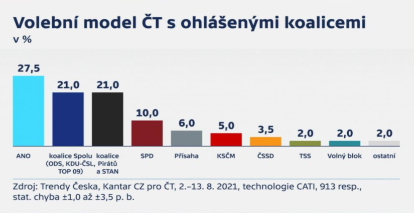

## Míru nejistoty můžeme vyjádřit také graficky

Zde data z července 2021.

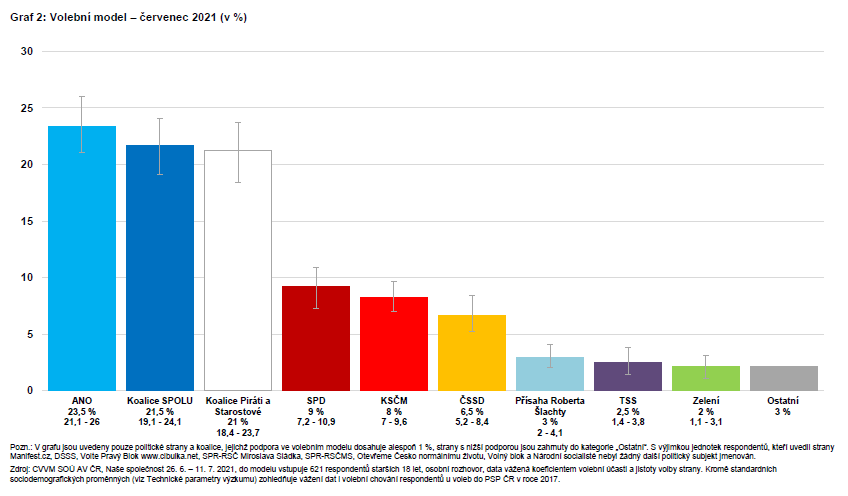

## Je na tomto grafu něco podezřelého?

Data ze září 2021.

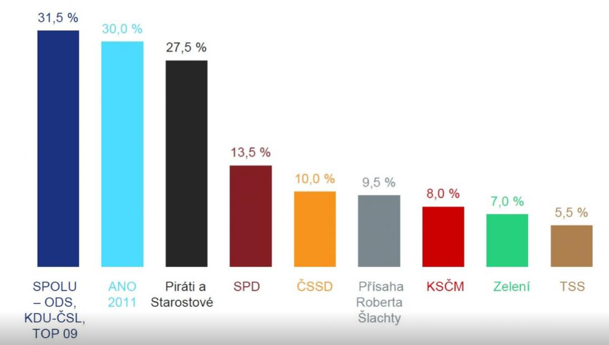

## Proč (moc) nepoužíváme koláčové graf?

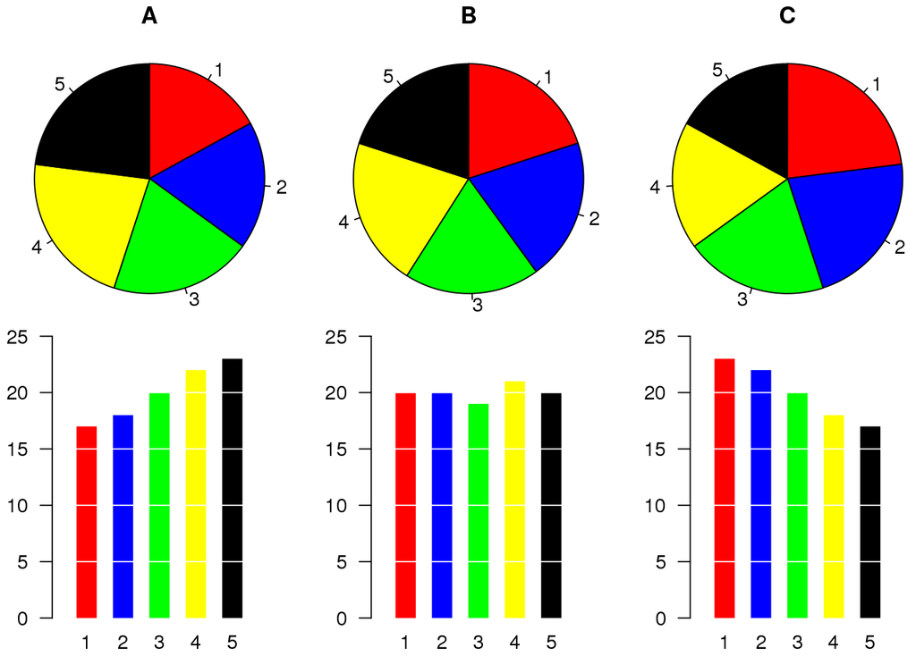

Zdroj: [Wikipedie](https://en.wikipedia.org/wiki/Pie_chart)

## Proč nepoužíváme 3D efekty?

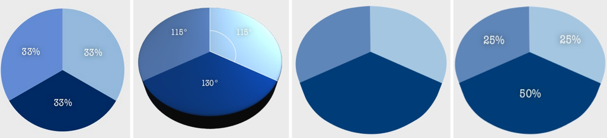

Zdroj: [Making data vizualizations - A survival guide](https://www.slideshare.net/vis4/making-data-visualizations-a-survival-guide)

## Osa Y

[figure not shown]

Zachyceno ve vysílání ČT.

## Arbitrární začátek osy Y

[figure not shown]

## Někdy to ale nemusí být tak jasné…

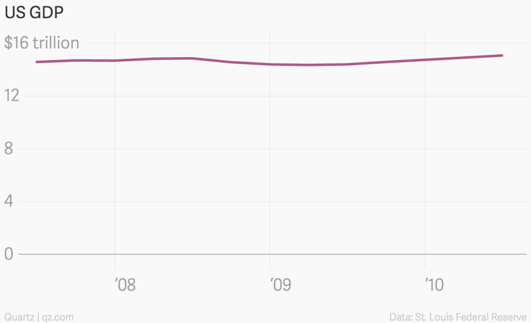

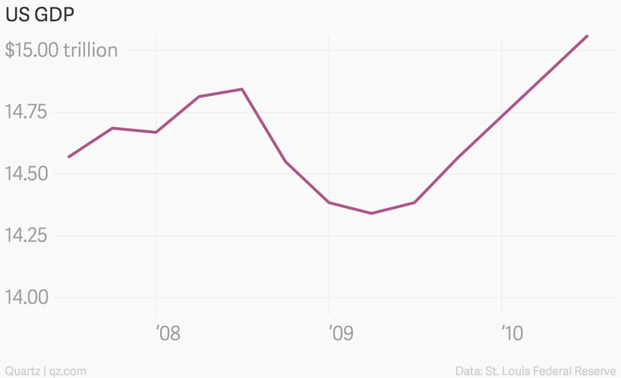

Zdroj [QUARTZ](https://qz.com/418083/its-ok-not-to-start-your-y-axis-at-zero/)

## To platí dvojnásob, pokud je 0 arbitrární

A pokud malé relativní rozdíly hrají velkou roli…

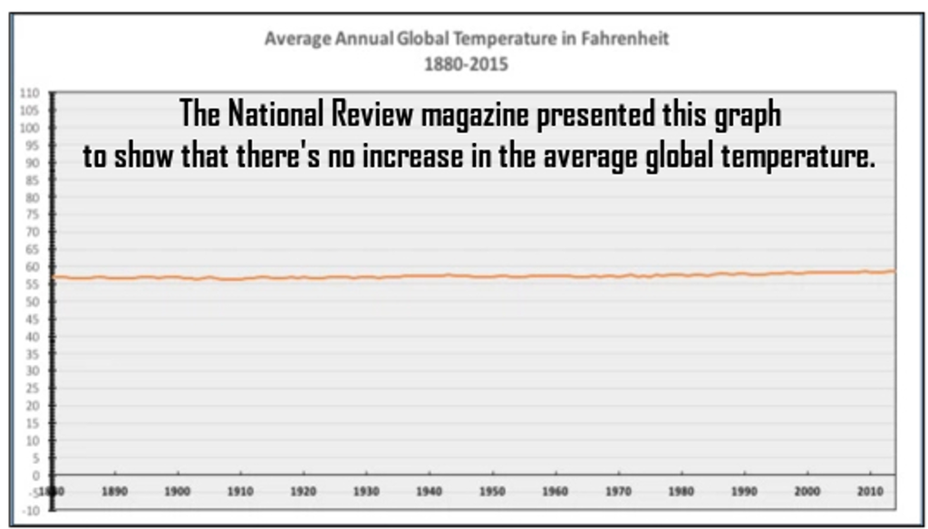

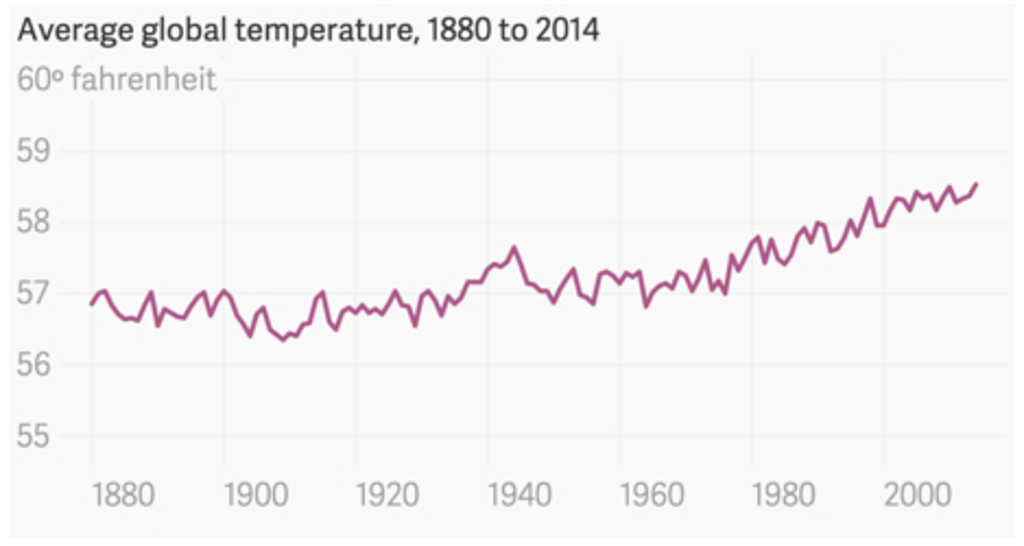

Zdroj [Cracked.com](http://www.cracked.com/photoplasty_2052_19-ways-you-can-make-statistics-say-whatever-you-want_p1/)

## Ostatní typy proměnných

## Metodologická perspektiva - Stevensova typologie (1946)

- nominální (nominal) - barva vlasů, náboženství
- ordinální (ordinal) - vůbec-trochu-hodně, ZŠ-SŠ-VŠ
- intervalové (interval) - teplota ve stupních Celsia
- poměrové (ratio) - příjem

[Původní Stevensův článek](https://www.jstor.org/stable/1671815?origin=JSTOR-pdf&seq=1#metadata_info_tab_contents). Kritika Stevensovy typologie - nadstavba

## Častá úprava Stevensovy typologie

- nominální (nominal)
- ordinální (ordinal)
- kardinální (cardinal, metric)
  - intervalové (interval)
  - poměrové (ratio)

## Příklad

Na této fotografii je 6 aut. Vůz číslo “99” (se žlutou střechou) je na 1. pozici.

[figure not shown]

Zdroj mathsisfun.com

## Alternativní prezentace Stevensovy typologie

- Kvalitativní proměnné (kategorické)
  - Nominální
  - Ordinální
- Kvantitativní proměnné (numerické, metrické)
  - Intervalové
  - Poměrové

## Matematická perspektiva na kvantitativní proměnné

- Diskrétní proměnné (count variables, spočetný počet)
- Spojité proměnné (continuous variables)

## Kategorická data - shrnutí

- Kategorická data jsou buď nominální, nebo ordinální.
- Jejich smyslem je uskupovat příbuzná pozorování.
- Často je analyticky uchopujeme skrze procenta a kontingenční tabulky (viz Analytická propedeutika)
- Speciální kategorií kategorických dat jsou data binární či dichotomická.

## Připomenutí kontingenční tabulky

|  | Západní země | Postsovětské | Total |
| --- | --- | --- | --- |
| Není člen EU | 60.0% (6) | 40.0% (4) | 100.0% (10) |
| Člen EU | 57.1% (16) | 42.9% (12) | 100.0% (28) |

## Kategorizace dat

- Kategorizace dat: Převod původně nekategorických dat na kategorická.
- Dichotomizace dat: Převod původně nebinárních dat na data binární.

## Reference v prezentaci

Následuje seznam referencí, které v prezentaci neměly aktivní proklik na zdroj.

Spiegelhalter, David. 2019. *The Art of Statistics: Learning from Data*. UK USA Canada Ireland Australia India New Zealand South Africa: Pelican.